# FoodHub Data Analysis

### Context

The number of restaurants in New York is increasing day by day. Lots of students and busy professionals rely on those restaurants due to their hectic lifestyles. Online food delivery service is a great option for them. It provides them with good food from their favorite restaurants. A food aggregator company FoodHub offers access to multiple restaurants through a single smartphone app.

The app allows the restaurants to receive a direct online order from a customer. The app assigns a delivery person from the company to pick up the order after it is confirmed by the restaurant. The delivery person then uses the map to reach the restaurant and waits for the food package. Once the food package is handed over to the delivery person, he/she confirms the pick-up in the app and travels to the customer's location to deliver the food. The delivery person confirms the drop-off in the app after delivering the food package to the customer. The customer can rate the order in the app. The food aggregator earns money by collecting a fixed margin of the delivery order from the restaurants.

### Objective

The food aggregator company has stored the data of the different orders made by the registered customers in their online portal. They want to analyze the data to get a fair idea about the demand of different restaurants which will help them in enhancing their customer experience. As a Data Scientist in this company there are some key questions that need to be answered. I have to perform a data analysis to find answers to these questions that will help the company to improve the business.

### Data Description

The data contains the different data related to a food order. The detailed data dictionary is given below.

### Data Dictionary

- order_id: Unique ID of the order
- customer_id: ID of the customer who ordered the food
- restaurant_name: Name of the restaurant
- cuisine_type: Cuisine ordered by the customer
- cost_of_the_order: Cost of the order
- day_of_the_week: Indicates whether the order is placed on a weekday or weekend (The weekday is from Monday to Friday and the weekend is Saturday and Sunday)
- rating: Rating given by the customer out of 5
- food_preparation_time: Time (in minutes) taken by the restaurant to prepare the food. This is calculated by taking the difference between the timestamps of the restaurant's order confirmation and the delivery person's pick-up confirmation.
- delivery_time: Time (in minutes) taken by the delivery person to deliver the food package. This is calculated by taking the difference between the timestamps of the delivery person's pick-up confirmation and drop-off information

### Let us start by importing the required libraries

```python
# Installing the libraries with the specified version.
# !pip install numpy==1.25.2 pandas==1.5.3 matplotlib==3.7.1 seaborn==0.13.1 -q --user
```

**Note**: *After running the above cell, kindly restart the notebook kernel and run all cells sequentially from the start again.*

```python
# import libraries for data manipulation
import numpy as np
import pandas as pd

# import libraries for data visualization
import matplotlib.pyplot as plt
import seaborn as sns
```

### Understanding the structure of the data

```python
# uncomment and run the following lines for Google Colab
from google.colab import drive
drive.mount('/content/drive')
```

```python
# Write your code here to read the data
# Reading FoodHub Master Data
data = pd.read_csv('/content/drive/MyDrive/content/foodhub_order.csv')
```

```python
# Write your code here to view the first 5 rows
# Reading 5 top rows
data.head()
```

|  | order_id | customer_id | restaurant_name | cuisine_type | cost_of_the_order | day_of_the_week | rating | food_preparation_time | delivery_time |
| --- | --- | --- | --- | --- | --- | --- | --- | --- | --- |
| 0 | 1477147 | 337525 | Hangawi | Korean | 30.75 | Weekend | Not given | 25 | 20 |
| 1 | 1477685 | 358141 | Blue Ribbon Sushi Izakaya | Japanese | 12.08 | Weekend | Not given | 25 | 23 |
| 2 | 1477070 | 66393 | Cafe Habana | Mexican | 12.23 | Weekday | 5 | 23 | 28 |
| 3 | 1477334 | 106968 | Blue Ribbon Fried Chicken | American | 29.20 | Weekend | 3 | 25 | 15 |
| 4 | 1478249 | 76942 | Dirty Bird to Go | American | 11.59 | Weekday | 4 | 25 | 24 |

### **Question 1:** How many rows and columns are present in the data?

```python
# Write your code here
print('Number of rows in the data:', data.shape[0])
print('Number of columns in the data:', data.shape[1])
```

```
Number of rows in the data: 1898
Number of columns in the data: 9
```

#### Observations:

- There are **1898** rows in the dataset and **9** columns

### **Question 2:** What are the datatypes of the different columns in the dataset?

```python
# Write your code here
data.info();
```

```
<class 'pandas.core.frame.DataFrame'>
RangeIndex: 1898 entries, 0 to 1897
Data columns (total 9 columns):
 #   Column                 Non-Null Count  Dtype
---  ------                 --------------  -----
 0   order_id               1898 non-null   int64
 1   customer_id            1898 non-null   int64
 2   restaurant_name        1898 non-null   object
 3   cuisine_type           1898 non-null   object
 4   cost_of_the_order      1898 non-null   float64
 5   day_of_the_week        1898 non-null   object
 6   rating                 1898 non-null   object
 7   food_preparation_time  1898 non-null   int64
 8   delivery_time          1898 non-null   int64
dtypes: float64(1), int64(4), object(4)
memory usage: 133.6+ KB
```

#### Observations:

- There are **5** numerical columns in the data and **4** object type columns

### **Question 3:** Are there any missing values in the data? If yes, treat them using an appropriate method.

*Checking for missing values:*

```python
# Write your code here
data.isnull().sum()
```

|  | 0 |
| --- | --- |
| order_id | 0 |
| customer_id | 0 |
| restaurant_name | 0 |
| cuisine_type | 0 |
| cost_of_the_order | 0 |
| day_of_the_week | 0 |
| rating | 0 |
| food_preparation_time | 0 |
| delivery_time | 0 |

**dtype:** int64

Using this space to convert columns to more related type for them

```python
data[['customer_id','order_id']]=data[['customer_id','order_id']].astype(object)
```

#### Observations:

- There are *no missing* values in the dataset

### **Question 4:** Check the statistical summary of the data. What is the minimum, average, and maximum time it takes for food to be prepared once an order is placed? [2 marks]

```python
# Write your code here
data.describe()
```

|  | order_id | customer_id | cost_of_the_order | food_preparation_time | delivery_time |
| --- | --- | --- | --- | --- | --- |
| count | 1.898000e+03 | 1898.000000 | 1898.000000 | 1898.000000 | 1898.000000 |
| mean | 1.477496e+06 | 171168.478398 | 16.498851 | 27.371970 | 24.161749 |
| std | 5.480497e+02 | 113698.139743 | 7.483812 | 4.632481 | 4.972637 |
| min | 1.476547e+06 | 1311.000000 | 4.470000 | 20.000000 | 15.000000 |
| 25% | 1.477021e+06 | 77787.750000 | 12.080000 | 23.000000 | 20.000000 |
| 50% | 1.477496e+06 | 128600.000000 | 14.140000 | 27.000000 | 25.000000 |
| 75% | 1.477970e+06 | 270525.000000 | 22.297500 | 31.000000 | 28.000000 |
| max | 1.478444e+06 | 405334.000000 | 35.410000 | 35.000000 | 33.000000 |

### **Question 5:** How many orders are not rated?

```python
# Write the code here
data.groupby('rating')['rating'].count()
```

| rating | rating |
| --- | --- |
| 3 | 188 |
| 4 | 386 |
| 5 | 588 |
| Not given | 736 |

**dtype:** int64

#### Observations:

- There are **736** orders where clients did not provide any rate
- There are **1162** orders with rate given **between 3 and 5**
- There are no orders with rates **between 1 and 2**

### Exploratory Data Analysis (EDA)

### **Question 6:** Explore all the variables and provide observations on their distributions. (Generally, histograms, boxplots, countplots, etc. are used for univariate exploration.) [9 marks]

1. **Cuisine Type**

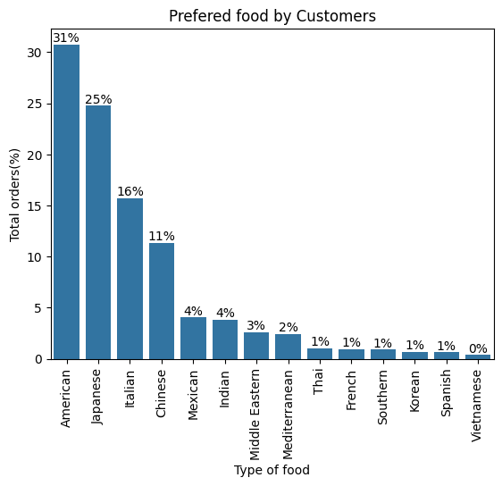

```python
chr = sns.countplot(data = data, x = 'cuisine_type', stat='percent',
                    legend=True, order=data['cuisine_type'].value_counts().index);
plt.xlabel('Type of food');
plt.ylabel('Total orders(%)');
plt.xticks(rotation=90);
plt.title('Prefered food by Customers');
chr.bar_label(chr.containers[0], fmt='%.0f%%');
plt.show()
```

1. **Cost of the order**

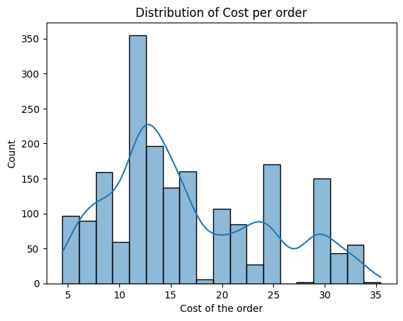

```python
# Write the code here
sns.histplot(data = data, x = 'cost_of_the_order', kde=True);
plt.xlabel('Cost of the order');
plt.ylabel('Count');
plt.title('Distribution of Cost per order');
plt.show()
```

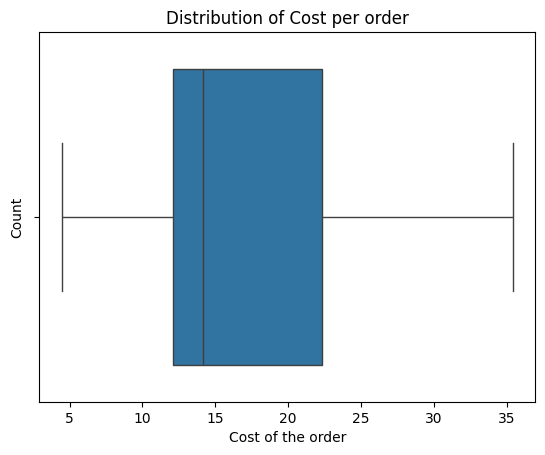

```python
sns.boxplot(data = data, x = 'cost_of_the_order');
plt.xlabel('Cost of the order');
plt.ylabel('Count');
plt.title('Distribution of Cost per order');
plt.show()
```

1. **Day of the week**

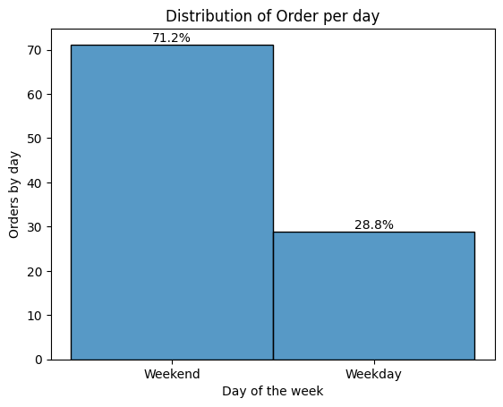

```python
chr = sns.histplot(data = data, x = 'day_of_the_week', stat='percent', legend=True);
plt.xlabel('Day of the week');
plt.ylabel('Orders by day');
plt.title('Distribution of Order per day');
chr.bar_label(chr.containers[0], fmt='%.1f%%');
plt.show()
```

1. **Rating**

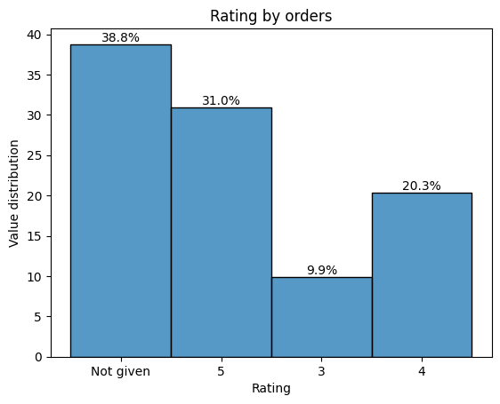

```python
chr = sns.histplot(data = data, x = 'rating', stat='percent', legend=True);
plt.xlabel('Rating');
plt.ylabel('Value distribution');
plt.title('Rating by orders');
chr.bar_label(chr.containers[0], fmt='%.1f%%');
plt.show()
```

Changing Rating to float and "Not Given" values to NaN:

```python
#Replace Not given values' with nan
data['rating'] = data['rating'].replace(['Not given'],np.nan)
#Convert the data type to a float
data['rating'] = data['rating'].astype(float)
```

1. **Food preparation time**

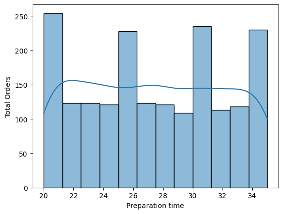

```python
chr = sns.histplot(data = data, x = 'food_preparation_time', legend=True, kde=True);
plt.xlabel('Preparation time');
plt.ylabel('Total Orders');
plt.show()
```

1. **Delivery time**

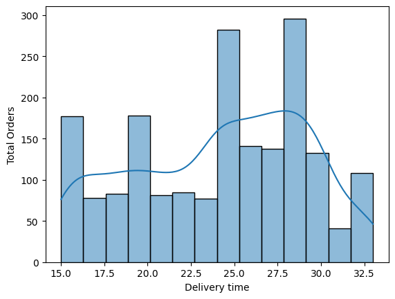

```python
chr = sns.histplot(data = data, x = 'delivery_time', legend=True, kde=True);
plt.xlabel('Delivery time');
plt.ylabel('Total Orders');
plt.show()
```

**Observations**

### **Question 7**: Which are the top 5 restaurants in terms of the number of orders received?

```python
# Write the code here
data['restaurant_name'].value_counts().nlargest(5)
```

```
restaurant_name
Shake Shack                  219
The Meatball Shop            132
Blue Ribbon Sushi            119
Blue Ribbon Fried Chicken     96
Parm                          68
Name: count, dtype: int64
```

#### Observations:

Top 5 restaurantes by orders received are:

1. Shake Shack (219)
2. The Meatball Shop (132)
3. Blue Ribbon Sushi (119)
4. Blue Ribbon Fried Chicken (96)
5. Parm (68)

### **Question 8**: Which is the most popular cuisine on weekends?

```python
# Write the code here
data.groupby('day_of_the_week')['cuisine_type'].value_counts().nlargest(1)
```

```
day_of_the_week  cuisine_type
Weekend          American        415
Name: count, dtype: int64
```

#### Observations:

The most popular food delivered on weekends is **American Food**

### **Question 9**: What percentage of the orders cost more than 20 dollars? [2 marks]

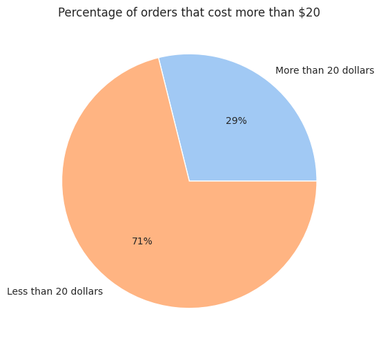

```python
# Write the code here
df_v = [data[data['cost_of_the_order']>20].shape[0]/data.shape[0]*100,
      data[data['cost_of_the_order']<21].shape[0]/data.shape[0]*100]
df_l = ['More than 20 dollars', 'Less than 20 dollars']
# Creating chart
plt.figure(figsize=(6,6))
sns.set_style("whitegrid")
sns.set_palette("pastel")
plt.pie(df_v, labels=df_l, autopct='%.0f%%')
# Add a title
plt.title("Percentage of orders that cost more than $20")

# Display the plot
plt.show()
```

#### Observations:

- Percentage or orders that cost more than 20 dollars is **29%**

### **Question 10**: What is the mean order delivery time?

```python
# Write the code here
round(data['delivery_time'].mean(), 1)
```

```
24.2
```

#### Observations:

- The average delivery time for orders is **24.2** minutes

### **Question 11:** The company has decided to give 20% discount vouchers to the top 3 most frequent customers. Find the IDs of these customers and the number of orders they placed.

```python
# Write the code here
data['customer_id'].value_counts().nlargest(3)
```

```
customer_id
52832    13
47440    10
83287     9
Name: count, dtype: int64
```

#### Observations:

Top 3 customers by orders submitted are:

1. 52832 (13)
2. 47440 (10)
3. 83287 (9)

### **Question 12**: Perform a multivariate analysis to explore relationships between the important variables in the dataset. (It is a good idea to explore relations between numerical variables as well as relations between numerical and categorical variables) [10 marks]

Change data types for the following questions in required columns

```python
#Convert the data type to a float
data['order_id'] = data['order_id'].astype(str)
data['customer_id'] = data['customer_id'].astype(str)
```

```python
data.info()
```

[output not shown]

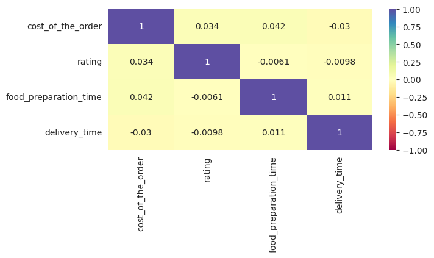

```python
# Write the code here
plt.figure(figsize=(7,3))
sns.heatmap(data=data[['cost_of_the_order', 'rating', 'food_preparation_time', 'delivery_time']].corr(), annot=True, cmap='Spectral', vmin=-1, vmax=1)
plt.show()
```

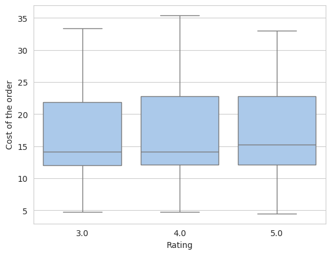

```python
sns.boxplot(data = data, x = 'rating', y = 'cost_of_the_order');
plt.xlabel('Rating');
plt.ylabel('Cost of the order');
plt.show()
```

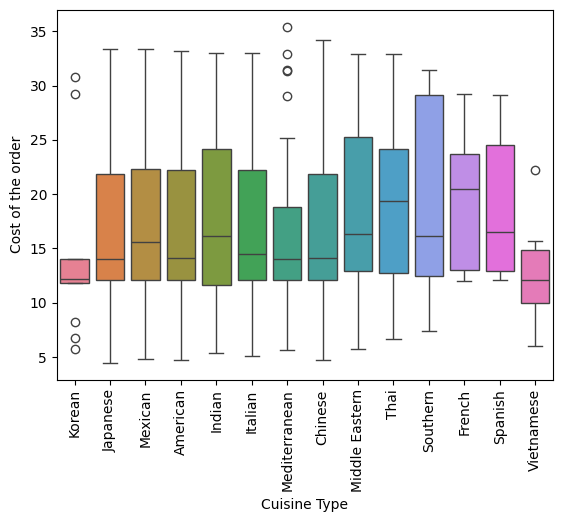

```python
sns.boxplot(data = data, x = 'cuisine_type', y = 'cost_of_the_order', hue='cuisine_type');
plt.xlabel('Cuisine Type');
plt.ylabel('Cost of the order');
plt.xticks(rotation=90);
plt.show()
```

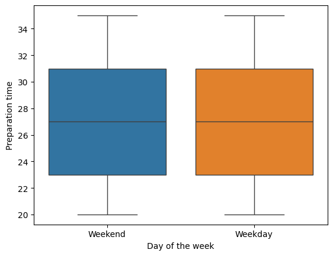

```python
sns.boxplot(data = data, x = 'day_of_the_week', y = 'food_preparation_time', hue='day_of_the_week');
plt.xlabel('Day of the week');
plt.ylabel('Preparation time');
plt.show()
```

#### Observations:

- There is no a strong correlation between variables to determine why users are selecting some specific restaurants.
- Notice how the rating is not affected by the cost of the order in the boxplot
- The analysis of cuisine type vs cost also reflects that cost is not the driver for people to select American food over Koren being the last one more affordable on average.
- Preparation time remains the same during weekdays and weekends

### **Question 13:** The company wants to provide a promotional offer in the advertisement of the restaurants. The condition to get the offer is that the restaurants must have a rating count of more than 50 and the average rating should be greater than 4. Find the restaurants fulfilling the criteria to get the promotional offer. [3 marks]

Creating a separate Dataframe to get restaurantes with rating mean and count

```python
# Write the code here
df = data.groupby('restaurant_name')['rating'].agg(['mean','count'])
```

[output not shown]

Filtering now restaurantes according to the conditions defined in the question

```python
df = df[(df['count']>50) & (df['mean']>4)]
df
```

| restaurant_name | mean | count |
| --- | --- | --- |
| Blue Ribbon Fried Chicken | 4.328125 | 64 |
| Blue Ribbon Sushi | 4.219178 | 73 |
| Shake Shack | 4.278195 | 133 |
| The Meatball Shop | 4.511905 | 84 |

#### Observations:

The restaurants that will get the promotional advertisement are:

1. Blue Ribbon Fried Chicken
2. Blue Ribbon Sushi
3. Shake Shack
4. The Meatball Shop

### **Question 14:** The company charges the restaurant 25% on the orders having cost greater than 20 dollars and 15% on the orders having cost greater than 5 dollars. Find the net revenue generated by the company across all orders. [3 marks]

Creating 2 separete datasets to get the revenue by category

```python
fd_20 = data[data['cost_of_the_order']>20]
fd_5 = data[(data['cost_of_the_order']>5) & (data['cost_of_the_order']<=20)]
```

Now let's compute the revenue by category

```python
fd_20_rv = fd_20['cost_of_the_order'].sum()*0.25
fd_5_rv = fd_5['cost_of_the_order'].sum()*0.15
```

Finally combining the 2 entries and pinting

```python
print(fd_20_rv + fd_5_rv)
```

```
6166.303
```

#### Observations:

- The total revenue generated by the company following the criteria defined is **6166.303 USD**

### **Question 15:** The company wants to analyze the total time required to deliver the food. What percentage of orders take more than 60 minutes to get delivered from the time the order is placed? (The food has to be prepared and then delivered.) [2 marks]

We first need to add a new column adding up both preparation time and delivery time. New column name is: total_delivery_time

```python
data['total_delivery_time'] = data['food_preparation_time'] + data['delivery_time']
```

Now we can work with the new column to filter values based on the criteria defined in the question and calculate the percentage of orders taken more than 1 hour

```python
round(data[data['total_delivery_time'] > 60].shape[0]/data.shape[0]*100, 2)
```

```
10.54
```

#### Observations:

- Around **10.54%** of the total orders took more than 1 hour to be delivered to the client from the moment they placed the order.

### **Question 16:** The company wants to analyze the delivery time of the orders on weekdays and weekends. How does the mean delivery time vary during weekdays and weekends? [2 marks]

```python
# Write the code here
data.groupby('day_of_the_week')['delivery_time'].mean().round(2)
```

```
day_of_the_week
Weekday    28.34
Weekend    22.47
Name: delivery_time, dtype: float64
```

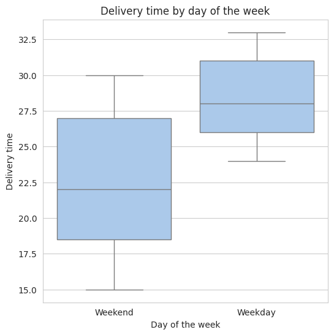

```python
plt.figure(figsize=(6,6))
sns.boxplot(data = data, x = 'day_of_the_week', y = 'delivery_time');
plt.xlabel('Day of the week');
plt.ylabel('Delivery time');
plt.title('Delivery time by day of the week');
plt.show()
```

#### Observations:

- During weekends the delivery time decreases and shows less max time. This might suggest that on weekends there are more people delivering food to customers making the waiting time shorter
- On Averange, clients need to wait **6** more minutes to get their orders delivered.

### Conclusion and Recommendations

### **Question 17:** What are your conclusions from the analysis? What recommendations would you like to share to help improve the business? (You can use cuisine type and feedback ratings to drive your business recommendations.) [6 marks]

### Conclusions:

- We can see a tendency for customers to get more American and Japanese and Italian orders.
- Orders during weekends represent 71% of the total received by restaurants.
- 10% of all orders are taking longer than expected for users going above 60 minutes of waiting time.
- There is no clear relationship between price and total orders received by restaurants.
- 38% of all orders delivered, do not get any feedback.
- The vast majority of orders (71%) cost below $20 which shows a tendency from the users to find food that is more budget friendly.